# Risk Factor Analysis

## Outcome Variable

**Outcome Variable:** wast_rec90d

## Predictor Variables

**Intervention Variable:** mhtcm

**Adjustment Set:**

- arm
- W_mage
- meducyrs
- feducyrs
- hhwealth_quart
- W_nrooms
- impfloor
- impsan
- safeh20
- delta_W_mage
- delta_meducyrs
- delta_feducyrs
- delta_hhwealth_quart
- delta_W_nrooms
- delta_impfloor
- delta_impsan
- delta_safeh20

## Stratifying Variables

The analysis was stratified on these variable(s):

- agecat
- studyid
- country

## Data Summary

| agecat | studyid | country | mhtcm | wast_rec90d | n_cell | n |
| --- | --- | --- | --- | --- | --- | --- |
| 0-24 months | ki0047075b-MAL-ED | BANGLADESH | >=155 cm | 0 | 4 | 122 |
| 0-24 months | ki0047075b-MAL-ED | BANGLADESH | >=155 cm | 1 | 5 | 122 |
| 0-24 months | ki0047075b-MAL-ED | BANGLADESH | <151 cm | 0 | 33 | 122 |
| 0-24 months | ki0047075b-MAL-ED | BANGLADESH | <151 cm | 1 | 51 | 122 |
| 0-24 months | ki0047075b-MAL-ED | BANGLADESH | [151-155) cm | 0 | 7 | 122 |
| 0-24 months | ki0047075b-MAL-ED | BANGLADESH | [151-155) cm | 1 | 22 | 122 |
| 0-24 months | ki0047075b-MAL-ED | BRAZIL | >=155 cm | 0 | 5 | 23 |
| 0-24 months | ki0047075b-MAL-ED | BRAZIL | >=155 cm | 1 | 12 | 23 |
| 0-24 months | ki0047075b-MAL-ED | BRAZIL | <151 cm | 0 | 1 | 23 |
| 0-24 months | ki0047075b-MAL-ED | BRAZIL | <151 cm | 1 | 4 | 23 |
| 0-24 months | ki0047075b-MAL-ED | BRAZIL | [151-155) cm | 0 | 0 | 23 |
| 0-24 months | ki0047075b-MAL-ED | BRAZIL | [151-155) cm | 1 | 1 | 23 |
| 0-24 months | ki0047075b-MAL-ED | INDIA | >=155 cm | 0 | 12 | 175 |
| 0-24 months | ki0047075b-MAL-ED | INDIA | >=155 cm | 1 | 17 | 175 |
| 0-24 months | ki0047075b-MAL-ED | INDIA | <151 cm | 0 | 44 | 175 |
| 0-24 months | ki0047075b-MAL-ED | INDIA | <151 cm | 1 | 49 | 175 |
| 0-24 months | ki0047075b-MAL-ED | INDIA | [151-155) cm | 0 | 14 | 175 |
| 0-24 months | ki0047075b-MAL-ED | INDIA | [151-155) cm | 1 | 39 | 175 |
| 0-24 months | ki0047075b-MAL-ED | NEPAL | >=155 cm | 0 | 3 | 93 |
| 0-24 months | ki0047075b-MAL-ED | NEPAL | >=155 cm | 1 | 6 | 93 |
| 0-24 months | ki0047075b-MAL-ED | NEPAL | <151 cm | 0 | 14 | 93 |
| 0-24 months | ki0047075b-MAL-ED | NEPAL | <151 cm | 1 | 45 | 93 |
| 0-24 months | ki0047075b-MAL-ED | NEPAL | [151-155) cm | 0 | 3 | 93 |
| 0-24 months | ki0047075b-MAL-ED | NEPAL | [151-155) cm | 1 | 22 | 93 |
| 0-24 months | ki0047075b-MAL-ED | PERU | >=155 cm | 0 | 0 | 34 |
| 0-24 months | ki0047075b-MAL-ED | PERU | >=155 cm | 1 | 3 | 34 |
| 0-24 months | ki0047075b-MAL-ED | PERU | <151 cm | 0 | 4 | 34 |
| 0-24 months | ki0047075b-MAL-ED | PERU | <151 cm | 1 | 23 | 34 |
| 0-24 months | ki0047075b-MAL-ED | PERU | [151-155) cm | 0 | 2 | 34 |
| 0-24 months | ki0047075b-MAL-ED | PERU | [151-155) cm | 1 | 2 | 34 |

[output cut: 378 more lines]

The following strata were considered:

- agecat: 0-24 months, studyid: ki0047075b-MAL-ED, country: BANGLADESH
- agecat: 0-24 months, studyid: ki0047075b-MAL-ED, country: BRAZIL
- agecat: 0-24 months, studyid: ki0047075b-MAL-ED, country: INDIA
- agecat: 0-24 months, studyid: ki0047075b-MAL-ED, country: NEPAL
- agecat: 0-24 months, studyid: ki0047075b-MAL-ED, country: PERU
- agecat: 0-24 months, studyid: ki0047075b-MAL-ED, country: SOUTH AFRICA
- agecat: 0-24 months, studyid: ki0047075b-MAL-ED, country: TANZANIA, UNITED REPUBLIC OF
- agecat: 0-24 months, studyid: ki1000304b-SAS-CompFeed, country: INDIA
- agecat: 0-24 months, studyid: ki1000304b-SAS-FoodSuppl, country: INDIA
- agecat: 0-24 months, studyid: ki1017093-NIH-Birth, country: BANGLADESH
- agecat: 0-24 months, studyid: ki1017093b-PROVIDE, country: BANGLADESH
- agecat: 0-24 months, studyid: ki1017093c-NIH-Crypto, country: BANGLADESH
- agecat: 0-24 months, studyid: ki1066203-TanzaniaChild2, country: TANZANIA, UNITED REPUBLIC OF
- agecat: 0-24 months, studyid: ki1101329-Keneba, country: GAMBIA
- agecat: 0-24 months, studyid: ki1112895-Guatemala BSC, country: GUATEMALA
- agecat: 0-24 months, studyid: ki1112895-iLiNS-Zinc, country: BURKINA FASO
- agecat: 0-24 months, studyid: ki1119695-PROBIT, country: BELARUS
- agecat: 0-24 months, studyid: ki1126311-ZVITAMBO, country: ZIMBABWE
- agecat: 0-24 months, studyid: ki1135781-COHORTS, country: GUATEMALA
- agecat: 0-24 months, studyid: ki1135781-COHORTS, country: INDIA
- agecat: 0-24 months, studyid: ki1135781-COHORTS, country: PHILIPPINES
- agecat: 0-24 months, studyid: ki1148112-LCNI-5, country: MALAWI
- agecat: 0-24 months, studyid: kiGH5241-JiVitA-3, country: BANGLADESH
- agecat: 0-6 months, studyid: ki0047075b-MAL-ED, country: BANGLADESH
- agecat: 0-6 months, studyid: ki0047075b-MAL-ED, country: BRAZIL
- agecat: 0-6 months, studyid: ki0047075b-MAL-ED, country: INDIA
- agecat: 0-6 months, studyid: ki0047075b-MAL-ED, country: NEPAL
- agecat: 0-6 months, studyid: ki0047075b-MAL-ED, country: PERU
- agecat: 0-6 months, studyid: ki0047075b-MAL-ED, country: SOUTH AFRICA
- agecat: 0-6 months, studyid: ki0047075b-MAL-ED, country: TANZANIA, UNITED REPUBLIC OF
- agecat: 0-6 months, studyid: ki1000304b-SAS-CompFeed, country: INDIA
- agecat: 0-6 months, studyid: ki1000304b-SAS-FoodSuppl, country: INDIA
- agecat: 0-6 months, studyid: ki1017093-NIH-Birth, country: BANGLADESH
- agecat: 0-6 months, studyid: ki1017093b-PROVIDE, country: BANGLADESH
- agecat: 0-6 months, studyid: ki1017093c-NIH-Crypto, country: BANGLADESH
- agecat: 0-6 months, studyid: ki1066203-TanzaniaChild2, country: TANZANIA, UNITED REPUBLIC OF
- agecat: 0-6 months, studyid: ki1101329-Keneba, country: GAMBIA
- agecat: 0-6 months, studyid: ki1112895-Guatemala BSC, country: GUATEMALA
- agecat: 0-6 months, studyid: ki1119695-PROBIT, country: BELARUS
- agecat: 0-6 months, studyid: ki1126311-ZVITAMBO, country: ZIMBABWE
- agecat: 0-6 months, studyid: ki1135781-COHORTS, country: GUATEMALA
- agecat: 0-6 months, studyid: ki1135781-COHORTS, country: INDIA
- agecat: 0-6 months, studyid: ki1135781-COHORTS, country: PHILIPPINES
- agecat: 0-6 months, studyid: ki1148112-LCNI-5, country: MALAWI
- agecat: 0-6 months, studyid: kiGH5241-JiVitA-3, country: BANGLADESH
- agecat: 6-24 months, studyid: ki0047075b-MAL-ED, country: BANGLADESH
- agecat: 6-24 months, studyid: ki0047075b-MAL-ED, country: BRAZIL
- agecat: 6-24 months, studyid: ki0047075b-MAL-ED, country: INDIA
- agecat: 6-24 months, studyid: ki0047075b-MAL-ED, country: NEPAL
- agecat: 6-24 months, studyid: ki0047075b-MAL-ED, country: PERU
- agecat: 6-24 months, studyid: ki0047075b-MAL-ED, country: SOUTH AFRICA
- agecat: 6-24 months, studyid: ki0047075b-MAL-ED, country: TANZANIA, UNITED REPUBLIC OF
- agecat: 6-24 months, studyid: ki1000304b-SAS-CompFeed, country: INDIA
- agecat: 6-24 months, studyid: ki1000304b-SAS-FoodSuppl, country: INDIA
- agecat: 6-24 months, studyid: ki1017093-NIH-Birth, country: BANGLADESH
- agecat: 6-24 months, studyid: ki1017093b-PROVIDE, country: BANGLADESH
- agecat: 6-24 months, studyid: ki1017093c-NIH-Crypto, country: BANGLADESH
- agecat: 6-24 months, studyid: ki1066203-TanzaniaChild2, country: TANZANIA, UNITED REPUBLIC OF
- agecat: 6-24 months, studyid: ki1101329-Keneba, country: GAMBIA
- agecat: 6-24 months, studyid: ki1112895-Guatemala BSC, country: GUATEMALA
- agecat: 6-24 months, studyid: ki1112895-iLiNS-Zinc, country: BURKINA FASO
- agecat: 6-24 months, studyid: ki1119695-PROBIT, country: BELARUS
- agecat: 6-24 months, studyid: ki1126311-ZVITAMBO, country: ZIMBABWE
- agecat: 6-24 months, studyid: ki1135781-COHORTS, country: GUATEMALA
- agecat: 6-24 months, studyid: ki1135781-COHORTS, country: INDIA
- agecat: 6-24 months, studyid: ki1135781-COHORTS, country: PHILIPPINES
- agecat: 6-24 months, studyid: ki1148112-LCNI-5, country: MALAWI
- agecat: 6-24 months, studyid: kiGH5241-JiVitA-3, country: BANGLADESH

### Dropped Strata

Some strata were dropped due to rare outcomes:

- agecat: 0-24 months, studyid: ki0047075b-MAL-ED, country: BANGLADESH
- agecat: 0-24 months, studyid: ki0047075b-MAL-ED, country: BRAZIL
- agecat: 0-24 months, studyid: ki0047075b-MAL-ED, country: NEPAL
- agecat: 0-24 months, studyid: ki0047075b-MAL-ED, country: PERU
- agecat: 0-24 months, studyid: ki0047075b-MAL-ED, country: SOUTH AFRICA
- agecat: 0-24 months, studyid: ki0047075b-MAL-ED, country: TANZANIA, UNITED REPUBLIC OF
- agecat: 0-24 months, studyid: ki1000304b-SAS-FoodSuppl, country: INDIA
- agecat: 0-24 months, studyid: ki1112895-Guatemala BSC, country: GUATEMALA
- agecat: 0-24 months, studyid: ki1112895-iLiNS-Zinc, country: BURKINA FASO
- agecat: 0-24 months, studyid: ki1119695-PROBIT, country: BELARUS
- agecat: 0-24 months, studyid: ki1148112-LCNI-5, country: MALAWI
- agecat: 0-6 months, studyid: ki0047075b-MAL-ED, country: BANGLADESH
- agecat: 0-6 months, studyid: ki0047075b-MAL-ED, country: BRAZIL
- agecat: 0-6 months, studyid: ki0047075b-MAL-ED, country: INDIA
- agecat: 0-6 months, studyid: ki0047075b-MAL-ED, country: NEPAL
- agecat: 0-6 months, studyid: ki0047075b-MAL-ED, country: PERU
- agecat: 0-6 months, studyid: ki0047075b-MAL-ED, country: SOUTH AFRICA
- agecat: 0-6 months, studyid: ki0047075b-MAL-ED, country: TANZANIA, UNITED REPUBLIC OF
- agecat: 0-6 months, studyid: ki1000304b-SAS-FoodSuppl, country: INDIA
- agecat: 0-6 months, studyid: ki1017093c-NIH-Crypto, country: BANGLADESH
- agecat: 0-6 months, studyid: ki1112895-Guatemala BSC, country: GUATEMALA
- agecat: 0-6 months, studyid: ki1119695-PROBIT, country: BELARUS
- agecat: 0-6 months, studyid: ki1148112-LCNI-5, country: MALAWI
- agecat: 6-24 months, studyid: ki0047075b-MAL-ED, country: BANGLADESH
- agecat: 6-24 months, studyid: ki0047075b-MAL-ED, country: BRAZIL
- agecat: 6-24 months, studyid: ki0047075b-MAL-ED, country: NEPAL
- agecat: 6-24 months, studyid: ki0047075b-MAL-ED, country: PERU
- agecat: 6-24 months, studyid: ki0047075b-MAL-ED, country: SOUTH AFRICA
- agecat: 6-24 months, studyid: ki0047075b-MAL-ED, country: TANZANIA, UNITED REPUBLIC OF
- agecat: 6-24 months, studyid: ki1000304b-SAS-FoodSuppl, country: INDIA
- agecat: 6-24 months, studyid: ki1017093b-PROVIDE, country: BANGLADESH
- agecat: 6-24 months, studyid: ki1017093c-NIH-Crypto, country: BANGLADESH
- agecat: 6-24 months, studyid: ki1112895-Guatemala BSC, country: GUATEMALA
- agecat: 6-24 months, studyid: ki1112895-iLiNS-Zinc, country: BURKINA FASO
- agecat: 6-24 months, studyid: ki1119695-PROBIT, country: BELARUS
- agecat: 6-24 months, studyid: ki1126311-ZVITAMBO, country: ZIMBABWE
- agecat: 6-24 months, studyid: ki1135781-COHORTS, country: GUATEMALA
- agecat: 6-24 months, studyid: ki1135781-COHORTS, country: INDIA
- agecat: 6-24 months, studyid: ki1148112-LCNI-5, country: MALAWI
- agecat: 6-24 months, studyid: kiGH5241-JiVitA-3, country: BANGLADESH

## Methods Detail

We’re interested in the causal parameters $E[Y_a]$ for all values of $a \in \mathcal{A}$. These parameters represent the mean outcome if, possibly contrary to fact, we intervened to set all units to have $A=a$. Under the randomization and positivity assumptions, these are identified by the statistical parameters $\psi_a=E_W[E_{Y|A,W}(Y|A=a,W)]$. In addition, we’re interested in the mean of $Y$, $E[Y]$ under no intervention (the observed mean). We will estimate these parameters by using SuperLearner to fit the relevant likelihood factors – $E_{Y|A,W}(Y|A=a,W)$ and $p(A=a|W)$, and then updating our likelihood fit using a joint TMLE.

For unadjusted analyses ($W=\{\}$), initial likelihoods were estimated using Lrnr_glm to estimate the simple $E(Y|A)$ and Lrnr_mean to estimate $p(A)$. For adjusted analyses, a small library containing Lrnr_glmnet, Lrnr_xgboost, and Lrnr_mean was used.

Having estimated these parameters, we will then use the delta method to estimate relative risks and attributable risks relative to a prespecified baseline level of $A$.

# Results Detail

## Results Plots

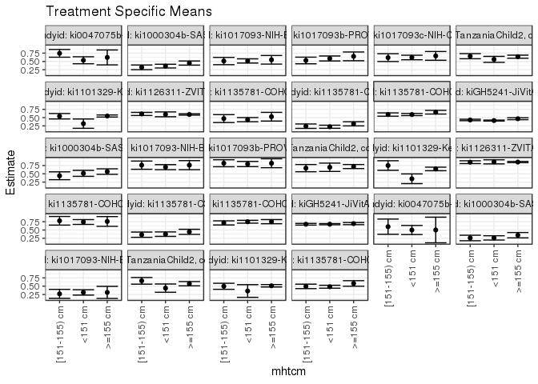

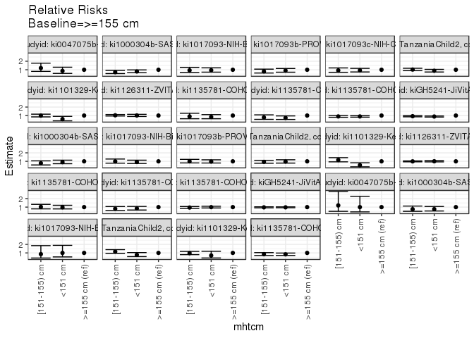

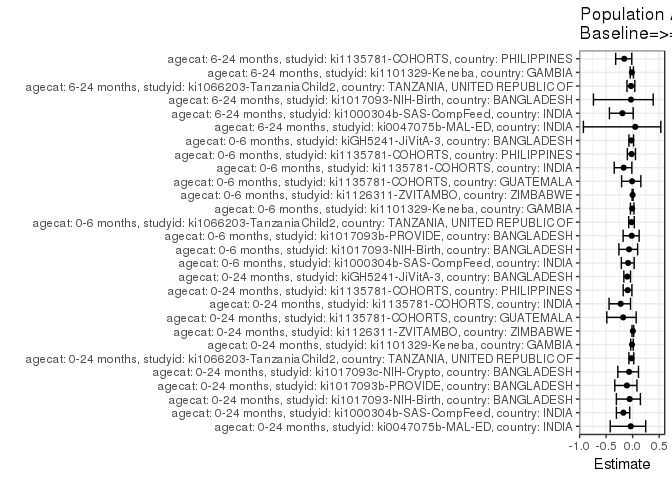

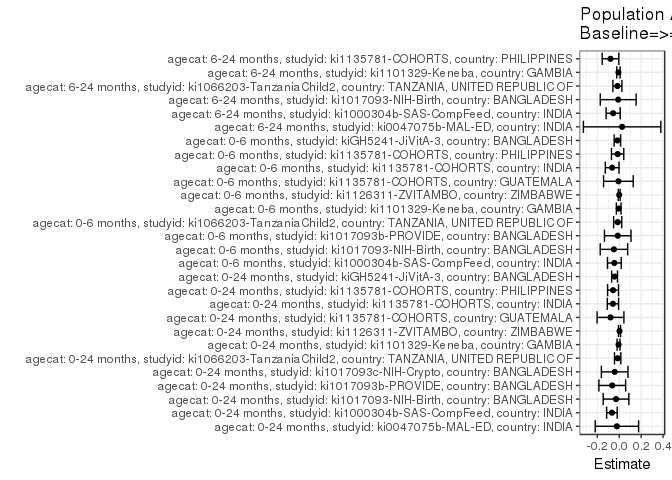

## Results Table

### Parameter: TSM

| agecat | studyid | country | intervention_level | baseline_level | estimate | ci_lower | ci_upper |
| --- | --- | --- | --- | --- | --- | --- | --- |
| 0-24 months | ki0047075b-MAL-ED | INDIA | >=155 cm | NA | 0.6210276 | 0.3963068 | 0.8457484 |
| 0-24 months | ki0047075b-MAL-ED | INDIA | <151 cm | NA | 0.5349465 | 0.4297110 | 0.6401821 |
| 0-24 months | ki0047075b-MAL-ED | INDIA | [151-155) cm | NA | 0.7443025 | 0.6276681 | 0.8609369 |
| 0-24 months | ki1000304b-SAS-CompFeed | INDIA | >=155 cm | NA | 0.4511559 | 0.3889122 | 0.5133996 |
| 0-24 months | ki1000304b-SAS-CompFeed | INDIA | <151 cm | NA | 0.3588934 | 0.3030536 | 0.4147331 |
| 0-24 months | ki1000304b-SAS-CompFeed | INDIA | [151-155) cm | NA | 0.3223296 | 0.2513701 | 0.3932891 |
| 0-24 months | ki1017093-NIH-Birth | BANGLADESH | >=155 cm | NA | 0.5492958 | 0.4196243 | 0.6789672 |
| 0-24 months | ki1017093-NIH-Birth | BANGLADESH | <151 cm | NA | 0.5151515 | 0.4516712 | 0.5786318 |
| 0-24 months | ki1017093-NIH-Birth | BANGLADESH | [151-155) cm | NA | 0.5116279 | 0.4024013 | 0.6208545 |
| 0-24 months | ki1017093b-PROVIDE | BANGLADESH | >=155 cm | NA | 0.6529534 | 0.5205215 | 0.7853854 |
| 0-24 months | ki1017093b-PROVIDE | BANGLADESH | <151 cm | NA | 0.5889737 | 0.5139700 | 0.6639774 |
| 0-24 months | ki1017093b-PROVIDE | BANGLADESH | [151-155) cm | NA | 0.5292314 | 0.4287731 | 0.6296897 |
| 0-24 months | ki1017093c-NIH-Crypto | BANGLADESH | >=155 cm | NA | 0.6674321 | 0.5348205 | 0.8000437 |
| 0-24 months | ki1017093c-NIH-Crypto | BANGLADESH | <151 cm | NA | 0.6190461 | 0.5508197 | 0.6872725 |
| 0-24 months | ki1017093c-NIH-Crypto | BANGLADESH | [151-155) cm | NA | 0.6146722 | 0.4974332 | 0.7319112 |
| 0-24 months | ki1066203-TanzaniaChild2 | TANZANIA, UNITED REPUBLIC OF | >=155 cm | NA | 0.6427538 | 0.5958003 | 0.6897072 |
| 0-24 months | ki1066203-TanzaniaChild2 | TANZANIA, UNITED REPUBLIC OF | <151 cm | NA | 0.5620636 | 0.4717565 | 0.6523706 |
| 0-24 months | ki1066203-TanzaniaChild2 | TANZANIA, UNITED REPUBLIC OF | [151-155) cm | NA | 0.6577070 | 0.5805933 | 0.7348208 |
| 0-24 months | ki1101329-Keneba | GAMBIA | >=155 cm | NA | 0.5484529 | 0.5169857 | 0.5799200 |
| 0-24 months | ki1101329-Keneba | GAMBIA | <151 cm | NA | 0.3182313 | 0.1779751 | 0.4584875 |
| 0-24 months | ki1101329-Keneba | GAMBIA | [151-155) cm | NA | 0.5417714 | 0.4598154 | 0.6237273 |
| 0-24 months | ki1126311-ZVITAMBO | ZIMBABWE | >=155 cm | NA | 0.5944368 | 0.5733992 | 0.6154744 |
| 0-24 months | ki1126311-ZVITAMBO | ZIMBABWE | <151 cm | NA | 0.5987558 | 0.5262802 | 0.6712315 |
| 0-24 months | ki1126311-ZVITAMBO | ZIMBABWE | [151-155) cm | NA | 0.6112432 | 0.5644596 | 0.6580268 |
| 0-24 months | ki1135781-COHORTS | GUATEMALA | >=155 cm | NA | 0.5274200 | 0.3957293 | 0.6591108 |
| 0-24 months | ki1135781-COHORTS | GUATEMALA | <151 cm | NA | 0.4385848 | 0.3761746 | 0.5009951 |
| 0-24 months | ki1135781-COHORTS | GUATEMALA | [151-155) cm | NA | 0.4704273 | 0.3515076 | 0.5893470 |
| 0-24 months | ki1135781-COHORTS | INDIA | >=155 cm | NA | 0.3133699 | 0.2507284 | 0.3760114 |
| 0-24 months | ki1135781-COHORTS | INDIA | <151 cm | NA | 0.2251512 | 0.1788607 | 0.2714418 |
| 0-24 months | ki1135781-COHORTS | INDIA | [151-155) cm | NA | 0.2417252 | 0.1754937 | 0.3079567 |

[output cut: 54 more lines]

### Parameter: E(Y)

| agecat | studyid | country | intervention_level | baseline_level | estimate | ci_lower | ci_upper |
| --- | --- | --- | --- | --- | --- | --- | --- |
| 0-24 months | ki0047075b-MAL-ED | INDIA | NA | NA | 0.6000000 | 0.5192868 | 0.6807132 |
| 0-24 months | ki1000304b-SAS-CompFeed | INDIA | NA | NA | 0.3844086 | 0.3477135 | 0.4211037 |
| 0-24 months | ki1017093-NIH-Birth | BANGLADESH | NA | NA | 0.5201900 | 0.4695846 | 0.5707955 |
| 0-24 months | ki1017093b-PROVIDE | BANGLADESH | NA | NA | 0.5894040 | 0.5323948 | 0.6464131 |
| 0-24 months | ki1017093c-NIH-Crypto | BANGLADESH | NA | NA | 0.6258065 | 0.5718723 | 0.6797406 |
| 0-24 months | ki1066203-TanzaniaChild2 | TANZANIA, UNITED REPUBLIC OF | NA | NA | 0.6283688 | 0.5905159 | 0.6662217 |
| 0-24 months | ki1101329-Keneba | GAMBIA | NA | NA | 0.5422222 | 0.5133413 | 0.5711031 |
| 0-24 months | ki1126311-ZVITAMBO | ZIMBABWE | NA | NA | 0.5971546 | 0.5785503 | 0.6157590 |
| 0-24 months | ki1135781-COHORTS | GUATEMALA | NA | NA | 0.4477212 | 0.3954919 | 0.4999504 |
| 0-24 months | ki1135781-COHORTS | INDIA | NA | NA | 0.2557143 | 0.2227697 | 0.2886589 |
| 0-24 months | ki1135781-COHORTS | PHILIPPINES | NA | NA | 0.6068680 | 0.5823645 | 0.6313715 |
| 0-24 months | kiGH5241-JiVitA-3 | BANGLADESH | NA | NA | 0.4230004 | 0.4118551 | 0.4341457 |
| 0-6 months | ki1000304b-SAS-CompFeed | INDIA | NA | NA | 0.5228758 | 0.4664267 | 0.5793250 |
| 0-6 months | ki1017093-NIH-Birth | BANGLADESH | NA | NA | 0.7130045 | 0.6535890 | 0.7724200 |
| 0-6 months | ki1017093b-PROVIDE | BANGLADESH | NA | NA | 0.8044693 | 0.7471161 | 0.8618224 |
| 0-6 months | ki1066203-TanzaniaChild2 | TANZANIA, UNITED REPUBLIC OF | NA | NA | 0.7053571 | 0.6558827 | 0.7548316 |
| 0-6 months | ki1101329-Keneba | GAMBIA | NA | NA | 0.6415094 | 0.5927496 | 0.6902692 |
| 0-6 months | ki1126311-ZVITAMBO | ZIMBABWE | NA | NA | 0.8543527 | 0.8380828 | 0.8706225 |
| 0-6 months | ki1135781-COHORTS | GUATEMALA | NA | NA | 0.7500000 | 0.6917133 | 0.8082867 |
| 0-6 months | ki1135781-COHORTS | INDIA | NA | NA | 0.3800425 | 0.3361595 | 0.4239255 |
| 0-6 months | ki1135781-COHORTS | PHILIPPINES | NA | NA | 0.7367021 | 0.7051294 | 0.7682749 |
| 0-6 months | kiGH5241-JiVitA-3 | BANGLADESH | NA | NA | 0.6759220 | 0.6625668 | 0.6892772 |
| 6-24 months | ki0047075b-MAL-ED | INDIA | NA | NA | 0.5263158 | 0.4116286 | 0.6410029 |
| 6-24 months | ki1000304b-SAS-CompFeed | INDIA | NA | NA | 0.2876712 | 0.2441703 | 0.3311721 |
| 6-24 months | ki1017093-NIH-Birth | BANGLADESH | NA | NA | 0.3030303 | 0.2377927 | 0.3682679 |
| 6-24 months | ki1066203-TanzaniaChild2 | TANZANIA, UNITED REPUBLIC OF | NA | NA | 0.5582656 | 0.5057575 | 0.6107737 |
| 6-24 months | ki1101329-Keneba | GAMBIA | NA | NA | 0.5045965 | 0.4711801 | 0.5380129 |
| 6-24 months | ki1135781-COHORTS | PHILIPPINES | NA | NA | 0.5026681 | 0.4688378 | 0.5364984 |

### Parameter: RR

| agecat | studyid | country | intervention_level | baseline_level | estimate | ci_lower | ci_upper |
| --- | --- | --- | --- | --- | --- | --- | --- |
| 0-24 months | ki0047075b-MAL-ED | INDIA | >=155 cm | >=155 cm | 1.0000000 | 1.0000000 | 1.0000000 |
| 0-24 months | ki0047075b-MAL-ED | INDIA | <151 cm | >=155 cm | 0.8613893 | 0.5710723 | 1.2992951 |
| 0-24 months | ki0047075b-MAL-ED | INDIA | [151-155) cm | >=155 cm | 1.1985015 | 0.8091024 | 1.7753080 |
| 0-24 months | ki1000304b-SAS-CompFeed | INDIA | >=155 cm | >=155 cm | 1.0000000 | 1.0000000 | 1.0000000 |
| 0-24 months | ki1000304b-SAS-CompFeed | INDIA | <151 cm | >=155 cm | 0.7954975 | 0.6465743 | 0.9787216 |
| 0-24 months | ki1000304b-SAS-CompFeed | INDIA | [151-155) cm | >=155 cm | 0.7144528 | 0.5511757 | 0.9260982 |
| 0-24 months | ki1017093-NIH-Birth | BANGLADESH | >=155 cm | >=155 cm | 1.0000000 | 1.0000000 | 1.0000000 |
| 0-24 months | ki1017093-NIH-Birth | BANGLADESH | <151 cm | >=155 cm | 0.9378399 | 0.7185622 | 1.2240329 |
| 0-24 months | ki1017093-NIH-Birth | BANGLADESH | [151-155) cm | >=155 cm | 0.9314252 | 0.6773642 | 1.2807774 |
| 0-24 months | ki1017093b-PROVIDE | BANGLADESH | >=155 cm | >=155 cm | 1.0000000 | 1.0000000 | 1.0000000 |
| 0-24 months | ki1017093b-PROVIDE | BANGLADESH | <151 cm | >=155 cm | 0.9020148 | 0.7098044 | 1.1462747 |
| 0-24 months | ki1017093b-PROVIDE | BANGLADESH | [151-155) cm | >=155 cm | 0.8105193 | 0.6138153 | 1.0702594 |
| 0-24 months | ki1017093c-NIH-Crypto | BANGLADESH | >=155 cm | >=155 cm | 1.0000000 | 1.0000000 | 1.0000000 |
| 0-24 months | ki1017093c-NIH-Crypto | BANGLADESH | <151 cm | >=155 cm | 0.9275043 | 0.7387605 | 1.1644696 |
| 0-24 months | ki1017093c-NIH-Crypto | BANGLADESH | [151-155) cm | >=155 cm | 0.9209509 | 0.6991985 | 1.2130326 |
| 0-24 months | ki1066203-TanzaniaChild2 | TANZANIA, UNITED REPUBLIC OF | >=155 cm | >=155 cm | 1.0000000 | 1.0000000 | 1.0000000 |
| 0-24 months | ki1066203-TanzaniaChild2 | TANZANIA, UNITED REPUBLIC OF | <151 cm | >=155 cm | 0.8744618 | 0.7330167 | 1.0432005 |
| 0-24 months | ki1066203-TanzaniaChild2 | TANZANIA, UNITED REPUBLIC OF | [151-155) cm | >=155 cm | 1.0232644 | 0.8913065 | 1.1747586 |
| 0-24 months | ki1101329-Keneba | GAMBIA | >=155 cm | >=155 cm | 1.0000000 | 1.0000000 | 1.0000000 |
| 0-24 months | ki1101329-Keneba | GAMBIA | <151 cm | >=155 cm | 0.5802345 | 0.3720297 | 0.9049603 |
| 0-24 months | ki1101329-Keneba | GAMBIA | [151-155) cm | >=155 cm | 0.9878176 | 0.8402648 | 1.1612810 |
| 0-24 months | ki1126311-ZVITAMBO | ZIMBABWE | >=155 cm | >=155 cm | 1.0000000 | 1.0000000 | 1.0000000 |
| 0-24 months | ki1126311-ZVITAMBO | ZIMBABWE | <151 cm | >=155 cm | 1.0072658 | 0.8879429 | 1.1426234 |
| 0-24 months | ki1126311-ZVITAMBO | ZIMBABWE | [151-155) cm | >=155 cm | 1.0282728 | 0.9451370 | 1.1187214 |
| 0-24 months | ki1135781-COHORTS | GUATEMALA | >=155 cm | >=155 cm | 1.0000000 | 1.0000000 | 1.0000000 |
| 0-24 months | ki1135781-COHORTS | GUATEMALA | <151 cm | >=155 cm | 0.8315666 | 0.6247395 | 1.1068660 |
| 0-24 months | ki1135781-COHORTS | GUATEMALA | [151-155) cm | >=155 cm | 0.8919405 | 0.6257655 | 1.2713356 |
| 0-24 months | ki1135781-COHORTS | INDIA | >=155 cm | >=155 cm | 1.0000000 | 1.0000000 | 1.0000000 |
| 0-24 months | ki1135781-COHORTS | INDIA | <151 cm | >=155 cm | 0.7184839 | 0.5396321 | 0.9566131 |
| 0-24 months | ki1135781-COHORTS | INDIA | [151-155) cm | >=155 cm | 0.7713734 | 0.5497413 | 1.0823580 |

[output cut: 54 more lines]

### Parameter: PAR

| agecat | studyid | country | intervention_level | baseline_level | estimate | ci_lower | ci_upper |
| --- | --- | --- | --- | --- | --- | --- | --- |
| 0-24 months | ki0047075b-MAL-ED | INDIA | >=155 cm | NA | -0.0210276 | -0.2188974 | 0.1768422 |
| 0-24 months | ki1000304b-SAS-CompFeed | INDIA | >=155 cm | NA | -0.0667473 | -0.1149202 | -0.0185744 |
| 0-24 months | ki1017093-NIH-Birth | BANGLADESH | >=155 cm | NA | -0.0291058 | -0.1461229 | 0.0879114 |
| 0-24 months | ki1017093b-PROVIDE | BANGLADESH | >=155 cm | NA | -0.0635495 | -0.1856243 | 0.0585253 |
| 0-24 months | ki1017093c-NIH-Crypto | BANGLADESH | >=155 cm | NA | -0.0416256 | -0.1627951 | 0.0795438 |
| 0-24 months | ki1066203-TanzaniaChild2 | TANZANIA, UNITED REPUBLIC OF | >=155 cm | NA | -0.0143850 | -0.0432217 | 0.0144518 |
| 0-24 months | ki1101329-Keneba | GAMBIA | >=155 cm | NA | -0.0062307 | -0.0194710 | 0.0070097 |
| 0-24 months | ki1126311-ZVITAMBO | ZIMBABWE | >=155 cm | NA | 0.0027178 | -0.0067604 | 0.0121961 |
| 0-24 months | ki1135781-COHORTS | GUATEMALA | >=155 cm | NA | -0.0796988 | -0.2019578 | 0.0425601 |
| 0-24 months | ki1135781-COHORTS | INDIA | >=155 cm | NA | -0.0576556 | -0.1090888 | -0.0062224 |
| 0-24 months | ki1135781-COHORTS | PHILIPPINES | >=155 cm | NA | -0.0563901 | -0.1061753 | -0.0066050 |
| 0-24 months | kiGH5241-JiVitA-3 | BANGLADESH | >=155 cm | NA | -0.0426317 | -0.0692088 | -0.0160547 |
| 0-6 months | ki1000304b-SAS-CompFeed | INDIA | >=155 cm | NA | -0.0444452 | -0.1072031 | 0.0183128 |
| 0-6 months | ki1017093-NIH-Birth | BANGLADESH | >=155 cm | NA | -0.0482491 | -0.1734287 | 0.0769304 |
| 0-6 months | ki1017093b-PROVIDE | BANGLADESH | >=155 cm | NA | -0.0137125 | -0.1347982 | 0.1073731 |
| 0-6 months | ki1066203-TanzaniaChild2 | TANZANIA, UNITED REPUBLIC OF | >=155 cm | NA | -0.0139633 | -0.0510937 | 0.0231671 |
| 0-6 months | ki1101329-Keneba | GAMBIA | >=155 cm | NA | -0.0047928 | -0.0259744 | 0.0163887 |
| 0-6 months | ki1126311-ZVITAMBO | ZIMBABWE | >=155 cm | NA | -0.0001409 | -0.0087035 | 0.0084217 |
| 0-6 months | ki1135781-COHORTS | GUATEMALA | >=155 cm | NA | -0.0075758 | -0.1429684 | 0.1278169 |
| 0-6 months | ki1135781-COHORTS | INDIA | >=155 cm | NA | -0.0643137 | -0.1269080 | -0.0017194 |
| 0-6 months | ki1135781-COHORTS | PHILIPPINES | >=155 cm | NA | -0.0147888 | -0.0709274 | 0.0413498 |
| 0-6 months | kiGH5241-JiVitA-3 | BANGLADESH | >=155 cm | NA | -0.0167198 | -0.0462334 | 0.0127938 |
| 6-24 months | ki0047075b-MAL-ED | INDIA | >=155 cm | NA | 0.0263158 | -0.3268414 | 0.3794730 |
| 6-24 months | ki1000304b-SAS-CompFeed | INDIA | >=155 cm | NA | -0.0553043 | -0.1196519 | 0.0090432 |
| 6-24 months | ki1017093-NIH-Birth | BANGLADESH | >=155 cm | NA | -0.0094697 | -0.1730023 | 0.1540629 |
| 6-24 months | ki1066203-TanzaniaChild2 | TANZANIA, UNITED REPUBLIC OF | >=155 cm | NA | -0.0165962 | -0.0576227 | 0.0244303 |
| 6-24 months | ki1101329-Keneba | GAMBIA | >=155 cm | NA | -0.0070887 | -0.0225133 | 0.0083359 |
| 6-24 months | ki1135781-COHORTS | PHILIPPINES | >=155 cm | NA | -0.0796104 | -0.1554859 | -0.0037349 |

### Parameter: PAF

| agecat | studyid | country | intervention_level | baseline_level | estimate | ci_lower | ci_upper |
| --- | --- | --- | --- | --- | --- | --- | --- |
| 0-24 months | ki0047075b-MAL-ED | INDIA | >=155 cm | NA | -0.0350460 | -0.4224851 | 0.2468672 |
| 0-24 months | ki1000304b-SAS-CompFeed | INDIA | >=155 cm | NA | -0.1736363 | -0.3060276 | -0.0546655 |
| 0-24 months | ki1017093-NIH-Birth | BANGLADESH | >=155 cm | NA | -0.0559522 | -0.3064224 | 0.1464973 |
| 0-24 months | ki1017093b-PROVIDE | BANGLADESH | >=155 cm | NA | -0.1078199 | -0.3364316 | 0.0816852 |
| 0-24 months | ki1017093c-NIH-Crypto | BANGLADESH | >=155 cm | NA | -0.0665152 | -0.2789301 | 0.1106202 |
| 0-24 months | ki1066203-TanzaniaChild2 | TANZANIA, UNITED REPUBLIC OF | >=155 cm | NA | -0.0228925 | -0.0698901 | 0.0220406 |
| 0-24 months | ki1101329-Keneba | GAMBIA | >=155 cm | NA | -0.0114910 | -0.0362303 | 0.0126578 |
| 0-24 months | ki1126311-ZVITAMBO | ZIMBABWE | >=155 cm | NA | 0.0045513 | -0.0114515 | 0.0203010 |
| 0-24 months | ki1135781-COHORTS | GUATEMALA | >=155 cm | NA | -0.1780100 | -0.4869975 | 0.0667722 |
| 0-24 months | ki1135781-COHORTS | INDIA | >=155 cm | NA | -0.2254689 | -0.4445712 | -0.0395984 |
| 0-24 months | ki1135781-COHORTS | PHILIPPINES | >=155 cm | NA | -0.0929199 | -0.1782253 | -0.0137908 |
| 0-24 months | kiGH5241-JiVitA-3 | BANGLADESH | >=155 cm | NA | -0.1007841 | -0.1654879 | -0.0396725 |
| 0-6 months | ki1000304b-SAS-CompFeed | INDIA | >=155 cm | NA | -0.0850014 | -0.2125784 | 0.0291531 |
| 0-6 months | ki1017093-NIH-Birth | BANGLADESH | >=155 cm | NA | -0.0676702 | -0.2588406 | 0.0944687 |
| 0-6 months | ki1017093b-PROVIDE | BANGLADESH | >=155 cm | NA | -0.0170455 | -0.1792690 | 0.1228621 |
| 0-6 months | ki1066203-TanzaniaChild2 | TANZANIA, UNITED REPUBLIC OF | >=155 cm | NA | -0.0197961 | -0.0738780 | 0.0315623 |
| 0-6 months | ki1101329-Keneba | GAMBIA | >=155 cm | NA | -0.0074712 | -0.0410345 | 0.0250101 |
| 0-6 months | ki1126311-ZVITAMBO | ZIMBABWE | >=155 cm | NA | -0.0001649 | -0.0102376 | 0.0098073 |
| 0-6 months | ki1135781-COHORTS | GUATEMALA | >=155 cm | NA | -0.0101010 | -0.2077661 | 0.1552139 |
| 0-6 months | ki1135781-COHORTS | INDIA | >=155 cm | NA | -0.1692276 | -0.3471114 | -0.0148330 |
| 0-6 months | ki1135781-COHORTS | PHILIPPINES | >=155 cm | NA | -0.0200743 | -0.0992551 | 0.0534030 |
| 0-6 months | kiGH5241-JiVitA-3 | BANGLADESH | >=155 cm | NA | -0.0247363 | -0.0693600 | 0.0180253 |
| 6-24 months | ki0047075b-MAL-ED | INDIA | >=155 cm | NA | 0.0500000 | -0.9284701 | 0.5320125 |
| 6-24 months | ki1000304b-SAS-CompFeed | INDIA | >=155 cm | NA | -0.1922484 | -0.4374607 | 0.0111338 |
| 6-24 months | ki1017093-NIH-Birth | BANGLADESH | >=155 cm | NA | -0.0312500 | -0.7392300 | 0.3885360 |
| 6-24 months | ki1066203-TanzaniaChild2 | TANZANIA, UNITED REPUBLIC OF | >=155 cm | NA | -0.0297281 | -0.1061641 | 0.0414261 |
| 6-24 months | ki1101329-Keneba | GAMBIA | >=155 cm | NA | -0.0140482 | -0.0451173 | 0.0160972 |
| 6-24 months | ki1135781-COHORTS | PHILIPPINES | >=155 cm | NA | -0.1583757 | -0.3198565 | -0.0166515 |